# Machine Learning Final Exam Project

## Calista Lianardi - 2702325880 - LE09

## 1. Liver Cirrhosis Model Classification

### 0. Importing Important Libraries

```python
#Importing Important Libraries

#Basic EDA Library
import pandas as pd
import numpy as np

#Plotting Library
import matplotlib.pyplot as plt
import seaborn as sns

#Preprocessing Library
from sklearn.preprocessing import LabelEncoder, StandardScaler
from sklearn.model_selection import train_test_split

#Machine Learning Model
from sklearn.model_selection import GridSearchCV, RandomizedSearchCV
from sklearn.ensemble import RandomForestClassifier
from sklearn.cluster import KMeans
from sklearn.metrics import accuracy_score, confusion_matrix, classification_report, ConfusionMatrixDisplay
import xgboost as xgb

# Remove warnings
from warnings import filterwarnings
filterwarnings('ignore')

pd.set_option('display.max_columns', None)
```

### 1.A. Exploratory Data Analysis

#### Data Preprocessing

```python
#Loading the dataset
df1 = pd.read_csv('1A.tsv', sep = '\t')
df1
```

|  | ID | Registration Date | Drug | Birth Date | Gender | Ascites | Hepatomegaly | Edema | Bilirubin | Cholesterol | Albumin | Copper | Alkaline Phospatase (U/L) | SGOT | Tryglicerides | Platelets | Prothrombin | Stage |
| --- | --- | --- | --- | --- | --- | --- | --- | --- | --- | --- | --- | --- | --- | --- | --- | --- | --- | --- |
| 0 | 1 | 2023/11/07 | D-penicillamine | 1966/03/07 | F | Y | Y | Y | 14.5 | 261.0 | 2.60 | 156.0 | 1718.0 | 137.95 | 172.0 | 190.0 | 12.2 | Stage4 |
| 1 | 2 | 2012/08/16 | D-penicillamine | 1968/07/01 | F | N | Y | N | 1.1 | 302.0 | 4.14 | 54.0 | 7394.8 | 113.52 | 88.0 | 221.0 | 10.6 | stage_3 |
| 2 | 3 | 2022/03/05 | D-penicillamine | 1954/11/15 | M | N | N | S | 1.4 | NaN | 3.48 | 210.0 | 516.0 | 96.10 | 55.0 | 151.0 | 12.0 | Stage4 |
| 3 | 4 | 2019/09/04 | D-penicillamine | 1970/03/16 | F | N | Y | S | 1.8 | 244.0 | 2.54 | 64.0 | 6121.8 | 60.63 | 92.0 | 183.0 | 10.3 | Stage4 |
| 4 | 5 | 2020/10/29 | Placebo | 1986/11/03 | F | N | Y | N | 3.4 | NaN | 3.53 | 143.0 | 671.0 | 113.15 | 72.0 | 136.0 | 10.9 | stage_3 |
| ... | ... | ... | ... | ... | ... | ... | ... | ... | ... | ... | ... | ... | ... | ... | ... | ... | ... | ... |
| 413 | 414 | 2023/01/30 | NaN | 1957/12/11 | F | NaN | NaN | N | 1.2 | NaN | 2.96 | NaN | NaN | NaN | -1.0 | 174.0 | 10.9 | stage_3 |
| 414 | 415 | 2021/12/04 | NaN | 1985/12/11 | F | NaN | NaN | N | 0.9 | NaN | 3.83 | NaN | NaN | NaN | -1.0 | 180.0 | 11.2 | Stage4 |
| 415 | 416 | 2022/01/21 | NaN | 1967/12/12 | F | NaN | NaN | N | 1.6 | NaN | 3.42 | NaN | NaN | NaN | -1.0 | 143.0 | 9.9 | stage_3 |
| 416 | 417 | 2023/01/20 | NaN | 1966/12/11 | F | NaN | NaN | N | 0.8 | NaN | 3.75 | NaN | NaN | NaN | -1.0 | 269.0 | 10.4 | stage_3 |
| 417 | 418 | 2022/04/10 | NaN | 1971/12/12 | F | NaN | NaN | N | 0.7 | NaN | 3.29 | NaN | NaN | NaN | -1.0 | 350.0 | 10.6 | Stage4 |

418 rows × 18 columns

```python
#checking the dataset summary
df1.info()
```

```
<class 'pandas.core.frame.DataFrame'>
RangeIndex: 418 entries, 0 to 417
Data columns (total 18 columns):
 #   Column                     Non-Null Count  Dtype
---  ------                     --------------  -----
 0   ID                         418 non-null    int64
 1   Registration Date          418 non-null    object
 2   Drug                       312 non-null    object
 3   Birth Date                 418 non-null    object
 4   Gender                     418 non-null    object
 5   Ascites                    312 non-null    object
 6   Hepatomegaly               312 non-null    object
 7   Edema                      418 non-null    object
 8   Bilirubin                  418 non-null    float64
 9   Cholesterol                80 non-null     float64
 10  Albumin                    418 non-null    float64
 11  Copper                     310 non-null    float64
 12  Alkaline Phospatase (U/L)  312 non-null    float64
 13  SGOT                       312 non-null    float64
 14  Tryglicerides              418 non-null    float64
 15  Platelets                  407 non-null    float64
 16  Prothrombin                416 non-null    float64
 17  Stage                      412 non-null    object
dtypes: float64(9), int64(1), object(8)
memory usage: 58.9+ KB
```

```python
#Summarry statistics
df1.describe()
```

|  | ID | Bilirubin | Cholesterol | Albumin | Copper | Alkaline Phospatase (U/L) | SGOT | Tryglicerides | Platelets | Prothrombin |
| --- | --- | --- | --- | --- | --- | --- | --- | --- | --- | --- |
| count | 418.000000 | 418.000000 | 80.000000 | 418.000000 | 310.000000 | 312.000000 | 312.000000 | 418.000000 | 407.000000 | 416.000000 |
| mean | 209.500000 | 3.220813 | 358.662500 | 3.497440 | 97.648387 | 1982.655769 | 122.556346 | 83.803828 | 257.024570 | 10.731731 |
| std | 120.810458 | 4.407506 | 230.414099 | 0.424972 | 85.613920 | 2140.388824 | 56.699525 | 79.603693 | 98.325585 | 1.022000 |
| min | 1.000000 | 0.300000 | 149.000000 | 1.960000 | 4.000000 | 289.000000 | 26.350000 | -1.000000 | 62.000000 | 9.000000 |
| 25% | 105.250000 | 0.800000 | 236.000000 | 3.242500 | 41.250000 | 871.500000 | 80.600000 | -1.000000 | 188.500000 | 10.000000 |
| 50% | 209.500000 | 1.400000 | 284.500000 | 3.530000 | 73.000000 | 1259.000000 | 114.700000 | 85.000000 | 251.000000 | 10.600000 |
| 75% | 313.750000 | 3.400000 | 409.500000 | 3.770000 | 123.000000 | 1980.000000 | 151.900000 | 127.750000 | 318.000000 | 11.100000 |
| max | 418.000000 | 28.000000 | 1480.000000 | 4.640000 | 588.000000 | 13862.400000 | 457.250000 | 598.000000 | 721.000000 | 18.000000 |

```python
#Checking unique value in each categorical cols

df1_cat = df1[['Drug', 'Gender', 'Ascites', 'Hepatomegaly', 'Edema', 'Stage']]

for i in df1_cat:
    print(df1[i].value_counts())
    print()
```

```
Drug
D-penicillamine    155
Placebo            152
d-penicillamine      3
placebo              1
lacebo               1
Name: count, dtype: int64

Gender
F    374
M     44
Name: count, dtype: int64

Ascites
N    288
Y     24
Name: count, dtype: int64

Hepatomegaly
Y    160
N    152
Name: count, dtype: int64

Edema
N    354
S     44
Y     20
Name: count, dtype: int64

Stage
stage_3    155
Stage4     144
Stage 2     92
Stage 1     21
Name: count, dtype: int64
```

```python
# Check for missing values
df1.isnull().sum()
```

```
ID                             0
Registration Date              0
Drug                         106
Birth Date                     0
Gender                         0
Ascites                      106
Hepatomegaly                 106
Edema                          0
Bilirubin                      0
Cholesterol                  338
Albumin                        0
Copper                       108
Alkaline Phospatase (U/L)    106
SGOT                         106
Tryglicerides                  0
Platelets                     11
Prothrombin                    2
Stage                          6
dtype: int64
```

```python
#Checking duplicated row
df1.duplicated().sum()
```

```
0
```

### Handling Anomalies and Missing Value

```python
#Dropping unneccessary column (ID, Registration Date, Birth Date)
#Cholesterol also as it having 90% of missing value

df1 = df1.drop(columns = ['ID', 'Registration Date', 'Birth Date', 'Cholesterol'])
df1.head()
```

|  | Drug | Gender | Ascites | Hepatomegaly | Edema | Bilirubin | Albumin | Copper | Alkaline Phospatase (U/L) | SGOT | Tryglicerides | Platelets | Prothrombin | Stage |
| --- | --- | --- | --- | --- | --- | --- | --- | --- | --- | --- | --- | --- | --- | --- |
| 0 | D-penicillamine | F | Y | Y | Y | 14.5 | 2.60 | 156.0 | 1718.0 | 137.95 | 172.0 | 190.0 | 12.2 | Stage4 |
| 1 | D-penicillamine | F | N | Y | N | 1.1 | 4.14 | 54.0 | 7394.8 | 113.52 | 88.0 | 221.0 | 10.6 | stage_3 |
| 2 | D-penicillamine | M | N | N | S | 1.4 | 3.48 | 210.0 | 516.0 | 96.10 | 55.0 | 151.0 | 12.0 | Stage4 |
| 3 | D-penicillamine | F | N | Y | S | 1.8 | 2.54 | 64.0 | 6121.8 | 60.63 | 92.0 | 183.0 | 10.3 | Stage4 |
| 4 | Placebo | F | N | Y | N | 3.4 | 3.53 | 143.0 | 671.0 | 113.15 | 72.0 | 136.0 | 10.9 | stage_3 |

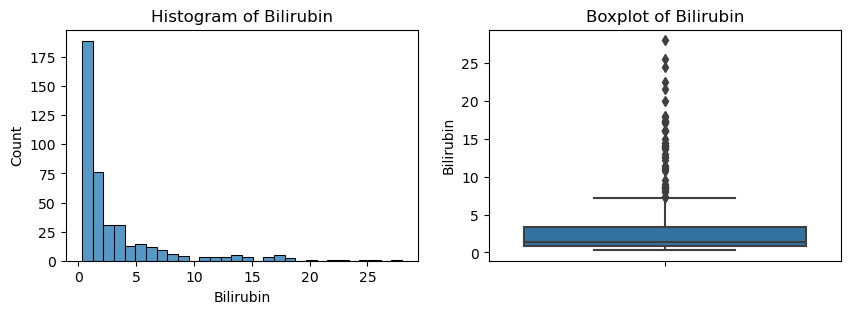

```
Skewness Bilirubin: 2.717610708740455
Kurtosis Bilirubin: 8.065335678744502
```

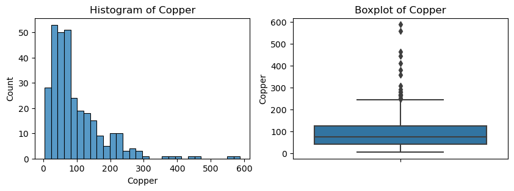

```
Skewness Copper: 2.3036399957832616
Kurtosis Copper: 7.624023449861701
```

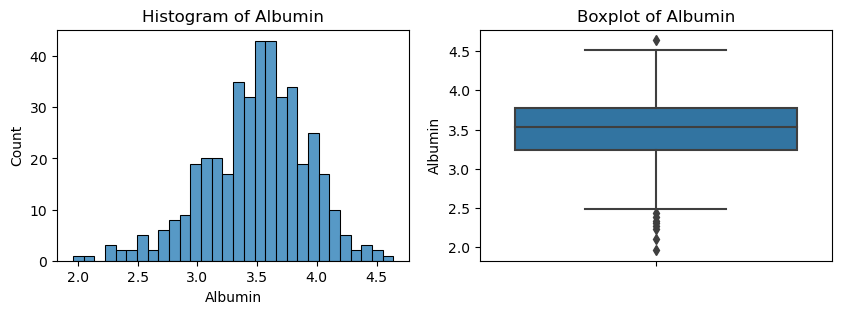

```
Skewness Albumin: -0.4675265141762801
Kurtosis Albumin: 0.5667445291024173
```

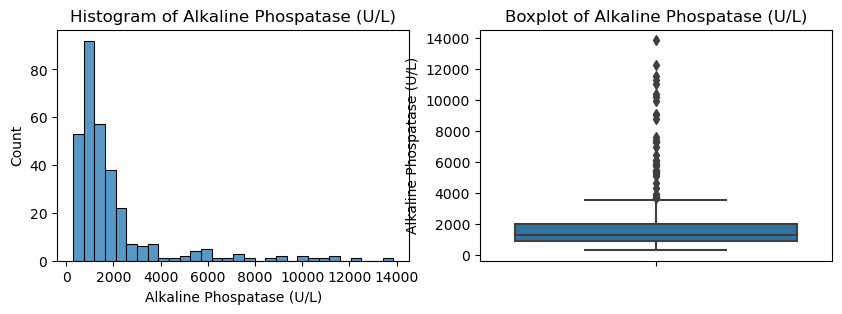

```
Skewness Alkaline Phospatase (U/L): 2.9928343153496115
Kurtosis Alkaline Phospatase (U/L): 9.662553460966153
```

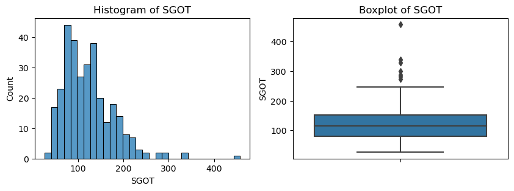

```
Skewness SGOT: 1.4491969235882083
Kurtosis SGOT: 4.311975857605217
```

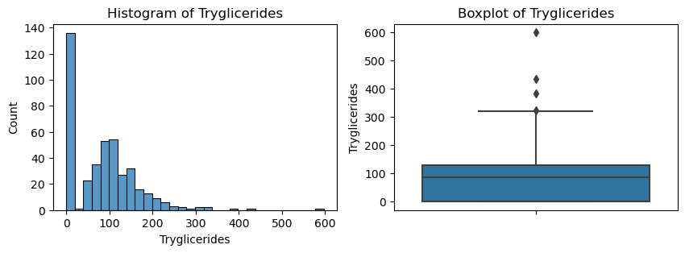

```
Skewness Tryglicerides: 1.325104892364005
Kurtosis Tryglicerides: 4.561155432600581
```

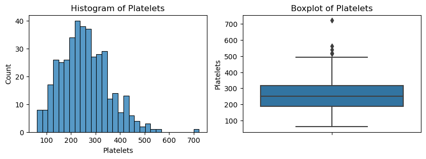

```
Skewness Platelets: 0.6270977603715678
Kurtosis Platelets: 0.8630445578915271
```

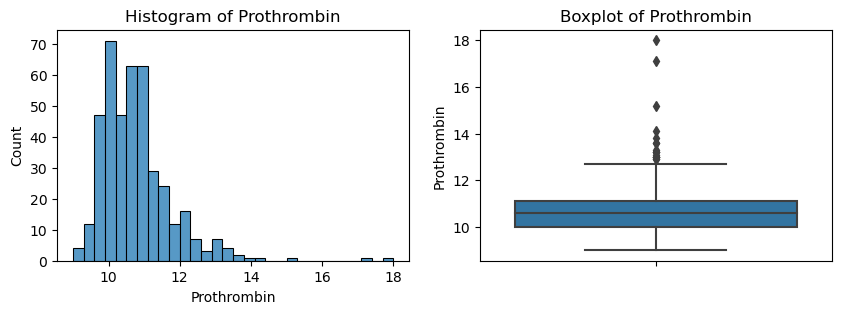

```
Skewness Prothrombin: 2.223276154109735
Kurtosis Prothrombin: 10.040772735082795
```

```python
#Evaluating distribution and outlier to impute the missing value

#Taking the numerical column
df1_numeric = df1[['Bilirubin', 'Copper', 'Albumin', 'Alkaline Phospatase (U/L)', 'SGOT', 'Tryglicerides', 'Platelets', 'Prothrombin']]
df1_numeric

def check_distribution_outliers(df, columns):
    for i in columns:
        plt.figure(figsize=(10, 3))

        plt.subplot(1, 2, 1)
        sns.histplot(df[i], bins=30)
        plt.title(f'Histogram of {i}')

        plt.subplot(1, 2, 2)
        sns.boxplot(y=df[i])
        plt.title(f'Boxplot of {i}')

        plt.show()

        print(f'Skewness {i}:', df[i].skew())
        print(f'Kurtosis {i}:', df[i].kurt())

check_distribution_outliers(df1, df1_numeric)
```

```python
#Imputing Missing Value

#Taking the categorical column
df1_categorical = df1[['Drug', 'Ascites', 'Hepatomegaly', 'Stage', 'Edema']]

#imputing the categorical columns using mode
for i in df1_categorical:
    df1[i] = df1[i].fillna(df1[i].mode()[0])

#imputing the normal distribution using median due to skewed distribution
#and existence of outliers
for i in df1_numeric:
    df1[i] = df1[i].fillna(df1[i].median())

df1.isnull().sum()
```

```
Drug                         0
Gender                       0
Ascites                      0
Hepatomegaly                 0
Edema                        0
Bilirubin                    0
Albumin                      0
Copper                       0
Alkaline Phospatase (U/L)    0
SGOT                         0
Tryglicerides                0
Platelets                    0
Prothrombin                  0
Stage                        0
dtype: int64
```

```python
#Cleaning anomalies in categorical column (especially 'Drug')

val_dict = {
    'D-penicillamine': 'D-penicillamine',
    'd-penicillamine': 'D-penicillamine',
    'Placebo': 'Placebo',
    'placebo': 'Placebo',
    'lacebo': 'Placebo'
}

df1['Drug'] = df1['Drug'].map(val_dict)

df1['Drug'].value_counts()
```

```
Drug
D-penicillamine    264
Placebo            154
Name: count, dtype: int64
```

```python
#Tidying up outcome variable so it's better in visual

df1['Stage'] = df1['Stage'].replace({
    'Stage 1': '1',
    'Stage 2': '2',
    'stage_3': '3',
    'Stage4': '4'
})
df1.head()
```

|  | Drug | Gender | Ascites | Hepatomegaly | Edema | Bilirubin | Albumin | Copper | Alkaline Phospatase (U/L) | SGOT | Tryglicerides | Platelets | Prothrombin | Stage |
| --- | --- | --- | --- | --- | --- | --- | --- | --- | --- | --- | --- | --- | --- | --- |
| 0 | D-penicillamine | F | Y | Y | Y | 14.5 | 2.60 | 156.0 | 1718.0 | 137.95 | 172.0 | 190.0 | 12.2 | 4 |
| 1 | D-penicillamine | F | N | Y | N | 1.1 | 4.14 | 54.0 | 7394.8 | 113.52 | 88.0 | 221.0 | 10.6 | 3 |
| 2 | D-penicillamine | M | N | N | S | 1.4 | 3.48 | 210.0 | 516.0 | 96.10 | 55.0 | 151.0 | 12.0 | 4 |
| 3 | D-penicillamine | F | N | Y | S | 1.8 | 2.54 | 64.0 | 6121.8 | 60.63 | 92.0 | 183.0 | 10.3 | 4 |
| 4 | Placebo | F | N | Y | N | 3.4 | 3.53 | 143.0 | 671.0 | 113.15 | 72.0 | 136.0 | 10.9 | 3 |

### Exploratory Data Analysis

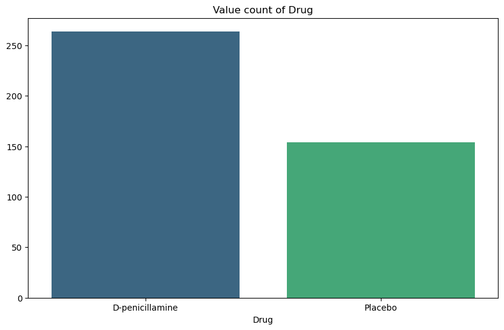

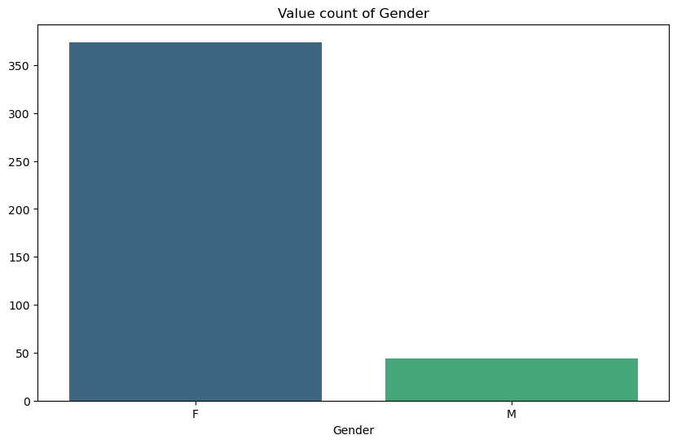

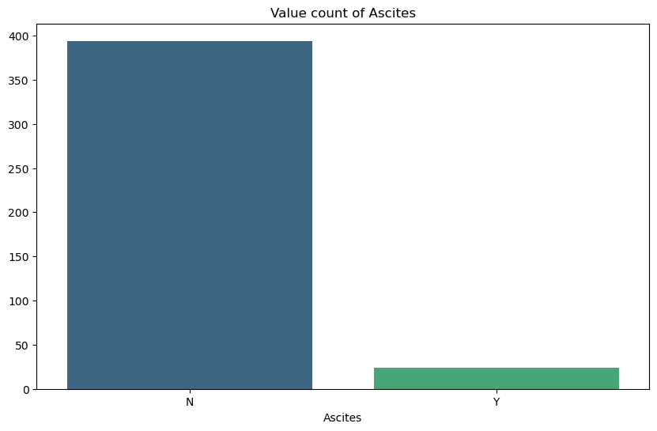

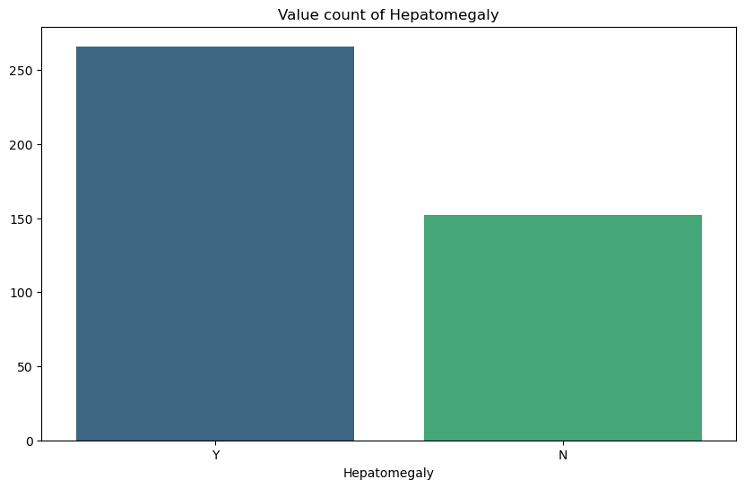

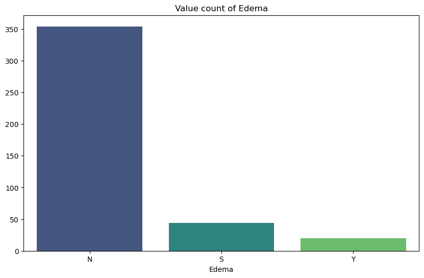

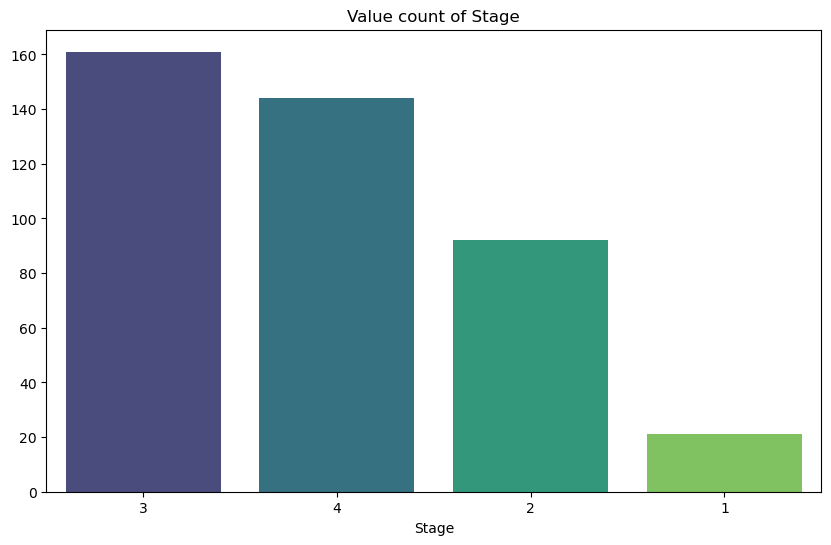

```python
# Plotting each categorical attribute

def plot_categorical_bar(df, column):
    value_count = df[column].value_counts()

    plt.figure(figsize=(10,6))
    sns.barplot(x=value_count.index, y=value_count.values, palette='viridis')
    plt.title(f'Value count of {column}')
    plt.show()

for col in df1_cat.columns.tolist():
    plot_categorical_bar(df1, col)
```

From this plot, we can interpret each categorical variable as:

The drug given for cirrhosis patient are mostly D-Penicillamine

Patients of hepatis cirrhosis are mostly woman

More patients do not experience ascites than do, this is probably because ascite often occurs as a complication in patients with high stages

Meanwhile the hepatomegaly mostly occurs in heapatis cirrhosis patient

Seeing the count of stage, most patients documented here are in stage 3, this might happen because at early stage the patient might not feel the discomfort yet and seeking medical assistance. due to this fact, it is best if we could make further analysis based on the stage

```python
#Doing groupby so it'll be easier to plot

stages = df1.groupby('Stage')
stg_df = {stage: data.drop('Stage', axis=1) for stage, data in stages}

s1 = stg_df['1']
s2 = stg_df['2']
s3 = stg_df['3']
s4 = stg_df['4']
```

```python
#Plotting

#Plotting Function
def categorical_distribution(col):
        plt.figure(figsize=(16, 4))

        plt.subplot(1, 4, 1)
        sns.countplot(data=s1, x=col, palette = 'viridis')
        plt.title(f'Stage 1 - {col}')

        plt.subplot(1, 4, 2)
        sns.countplot(data=s2, x=col, palette = 'viridis')
        plt.title(f'Stage 2 - {col}')

        plt.subplot(1, 4, 3)
        sns.countplot(data=s3, x=col, palette = 'viridis')
        plt.title(f'Stage 3 - {col}')

        plt.subplot(1, 4, 4)
        sns.countplot(data=s4, x=col, palette = 'viridis')
        plt.title(f'Stage 4 - {col}')

        plt.show()
```

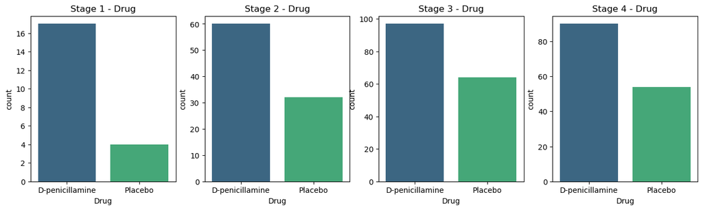

```python
#Plotting on Drug

categorical_distribution('Drug')
```

Category 1: Drug

Here in drug, there doesn't seem much to be a trend, just proving the point that most hepatis cirrhosis patient are treated with D Penicilamine, but seeing the Placebo trend might increasing, we suppose that Placebo started to become a choice in higher stage of cirrhosis

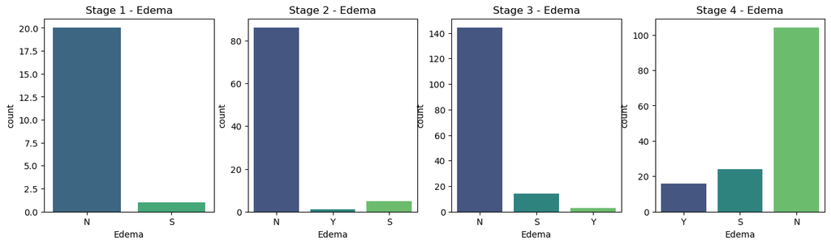

```python
#PLotting on Edema

categorical_distribution('Edema')
```

Category 2: Edema

I don't get why at stage 4 plot they become reversed in order. but all we can see is the fact that the trend happen on (S = Edema Without Diuretics), that higher the stage, higher the possibilities of hepatis cirrhosis patient suffer from edema, although the number of (Y = Edema despite diuretics) seems increasing in trend, it may because edema are often happen in patients with higher stage, but seeing the number still below (S), it indicates giving diuretic medication to patients with edema might be effective in relieving the edema

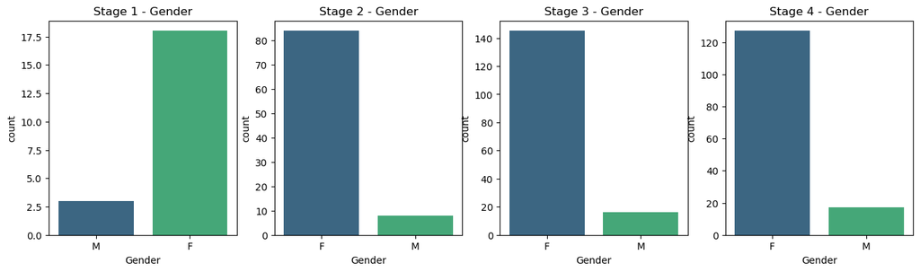

```python
#PLotting on Gender

categorical_distribution('Gender')
```

Category 3: Gender

Based on the plot, hepatis cirrhosis patient are dominated by woman, indicating that woman might be more prone to hepatis cirrhosis in this sample pool

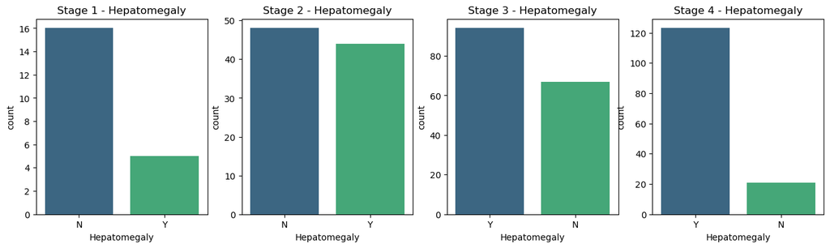

```python
#PLotting on Hepatomegaly

categorical_distribution('Hepatomegaly')
```

Category 4: Hepatomegaly

Hepatomegaly means enlargement of liver. Based on the plot, it quite visible that starting from stage 3, the patient of cirrhosis might suffer with enlargement of the liver organ as the complication of the illness, while in lower stage the Yes:No ratio are dominated with N supporting our finding that Hepatomegaly often happen starting from stage 3

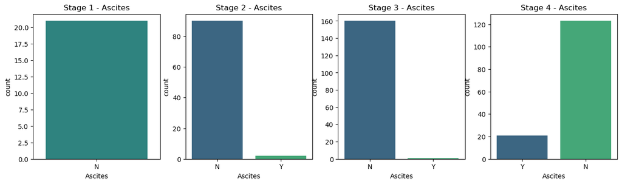

```python
#PLotting on Ascites

categorical_distribution('Ascites')
```

Category 5: Ascites

Ascites is where the fluids build up in the abdomen as a complication of hepatis cirrhosis. Based on the plot, although this complication might be not that popular in hepatis cirrhosis patient, there are some trend seen in the Yes, as starting in stage 4, the Y seems to have a spike indicating that this complication often happen in stage 4 where the liver are in total failure condition

##### Let's now do feature engineering to explore the numerical variable

```python
#Feature Engineering
#(Adding additional column to do crosstab analysis)

df1['Bilirubin_Status'] = df1['Bilirubin'].apply(lambda x: 'Abnormal' if x > 1.2 else 'Normal')
df1['Albumin_Status'] = df1['Albumin'].apply(lambda x: 'Abnormal' if x < 5.4 or x > 3.4 else 'Normal')
df1['Copper_Status'] = df1['Copper'].apply(lambda x: 'Abnormal' if x > 140 else 'Normal')
df1['Alkaline_Phosphatase_Status'] = df1['Alkaline Phospatase (U/L)'].apply(lambda x: 'Abnormal' if x > 147 else 'Normal')  # Adjust threshold
df1['SGOT_Status'] = df1['SGOT'].apply(lambda x: 'Abnormal' if x > 40 else 'Normal')
df1['Triglycerides_Status'] = df1['Tryglicerides'].apply(lambda x: 'Abnormal' if x > 150 else 'Normal')
df1['Platelets_Status'] = df1['Platelets'].apply(lambda x: 'Abnormal' if x < 150 else 'Normal')
df1['Prothrombin_Status'] = df1['Prothrombin'].apply(lambda x: 'Abnormal' if x < 70 else 'Normal')
df1.head()
```

|  | Drug | Gender | Ascites | Hepatomegaly | Edema | Bilirubin | Albumin | Copper | Alkaline Phospatase (U/L) | SGOT | Tryglicerides | Platelets | Prothrombin | Stage | Bilirubin_Status | Albumin_Status | Copper_Status | Alkaline_Phosphatase_Status | SGOT_Status | Triglycerides_Status | Platelets_Status | Prothrombin_Status |
| --- | --- | --- | --- | --- | --- | --- | --- | --- | --- | --- | --- | --- | --- | --- | --- | --- | --- | --- | --- | --- | --- | --- |
| 0 | D-penicillamine | F | Y | Y | Y | 14.5 | 2.60 | 156.0 | 1718.0 | 137.95 | 172.0 | 190.0 | 12.2 | 4 | Abnormal | Abnormal | Abnormal | Abnormal | Abnormal | Abnormal | Normal | Abnormal |
| 1 | D-penicillamine | F | N | Y | N | 1.1 | 4.14 | 54.0 | 7394.8 | 113.52 | 88.0 | 221.0 | 10.6 | 3 | Normal | Abnormal | Normal | Abnormal | Abnormal | Normal | Normal | Abnormal |
| 2 | D-penicillamine | M | N | N | S | 1.4 | 3.48 | 210.0 | 516.0 | 96.10 | 55.0 | 151.0 | 12.0 | 4 | Abnormal | Abnormal | Abnormal | Abnormal | Abnormal | Normal | Normal | Abnormal |
| 3 | D-penicillamine | F | N | Y | S | 1.8 | 2.54 | 64.0 | 6121.8 | 60.63 | 92.0 | 183.0 | 10.3 | 4 | Abnormal | Abnormal | Normal | Abnormal | Abnormal | Normal | Normal | Abnormal |
| 4 | Placebo | F | N | Y | N | 3.4 | 3.53 | 143.0 | 671.0 | 113.15 | 72.0 | 136.0 | 10.9 | 3 | Abnormal | Abnormal | Abnormal | Abnormal | Abnormal | Normal | Abnormal | Abnormal |

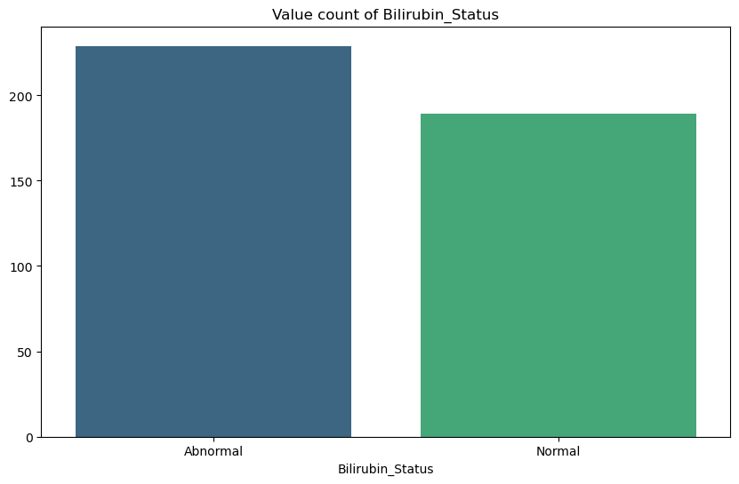

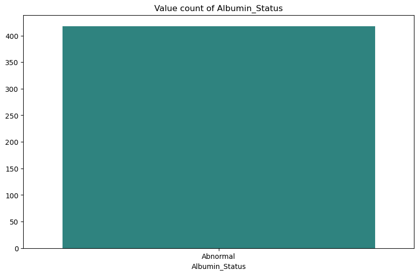

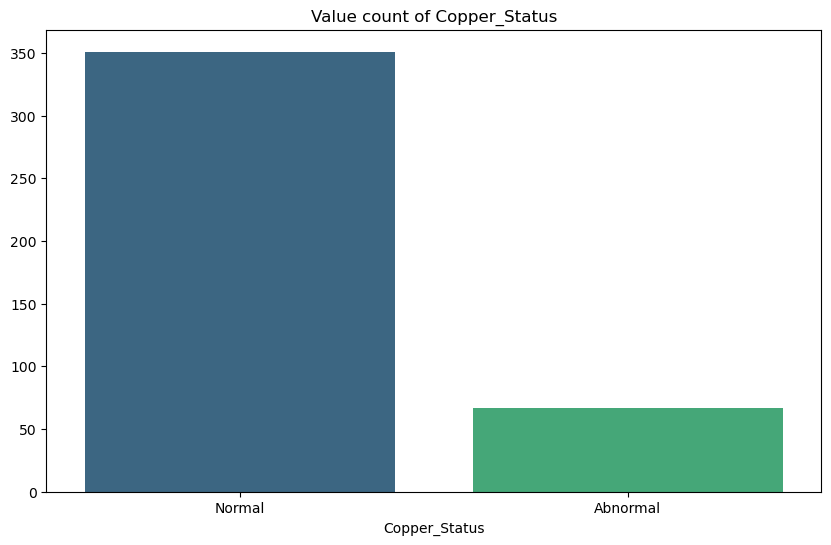

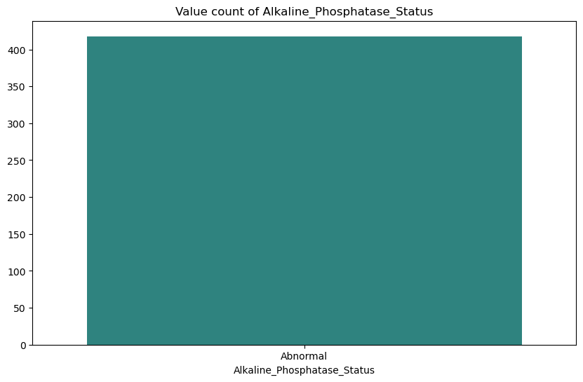

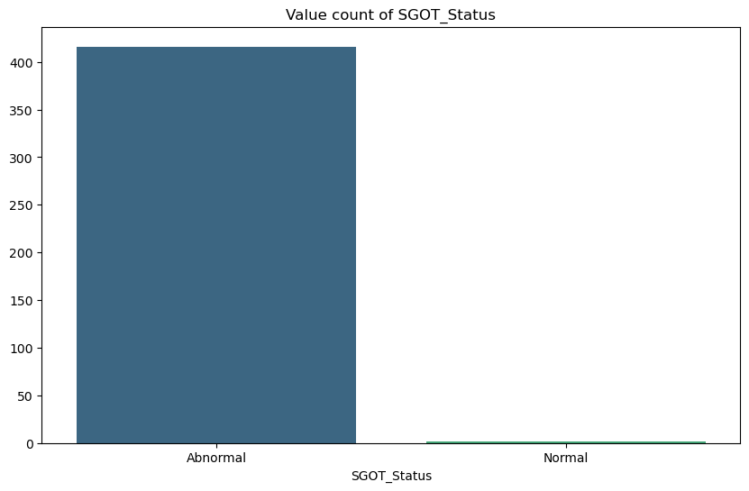

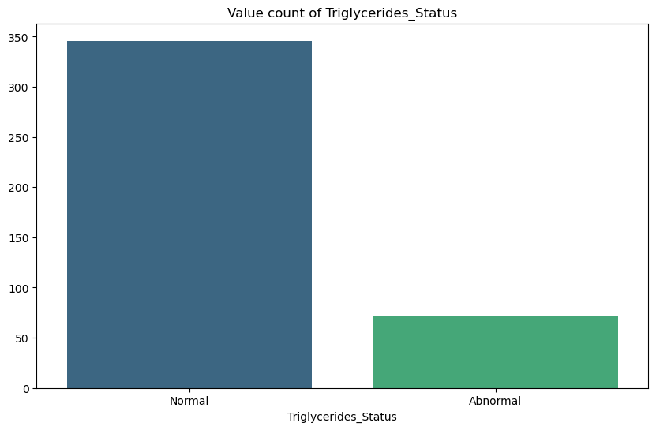

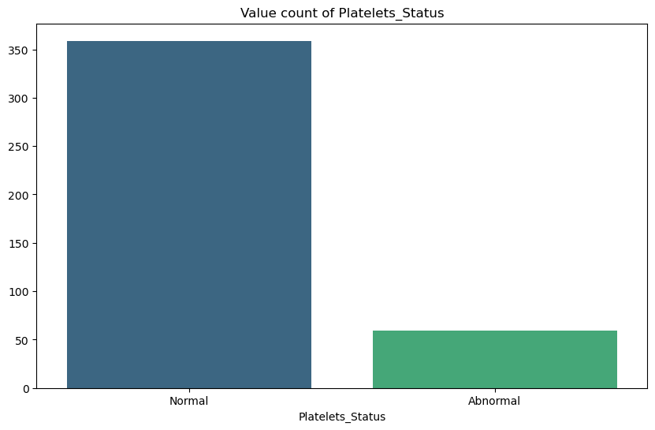

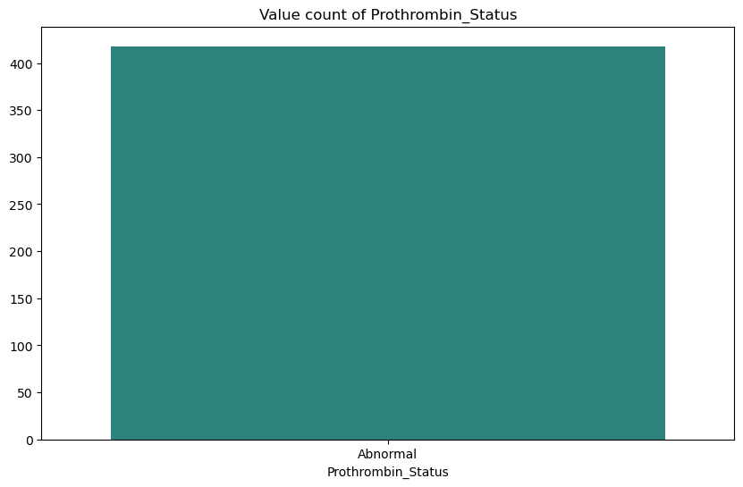

```python
#Plotting each numerical attribute status

status_col = ['Bilirubin_Status', 'Albumin_Status', 'Copper_Status', 'Alkaline_Phosphatase_Status', 'SGOT_Status', 'Triglycerides_Status', 'Platelets_Status', 'Prothrombin_Status']

for col in status_col:
    plot_categorical_bar(df1, col)
```

I add additional column here to do crosstab analysis between every numerical attribute and stage

Bilirubin: seeing the distribution of abnormal and normal, seems like many of hepatis cirrhosis patient suffer from abnormal level of bilirubin, where medically bilirubin often associates with every kind of hepatitis, indicated visualy by skin and eye yellowing

Alkaline Phospatase: from the plot we can see that all cirrhosis patient suffering from abnormal ALP Level, this is medically fact that cirrhosis can cause elevated levels of ALP, as ALP levels usually used to predict the outcome of cirrhosis patient

SGOT: High sgot level can indicating liver failure, especially hepatis cirrhosis. based on the plot, although patient with normal ammount of sgot might exist, the patient are dominated by abnormal level of SGOT, the existence of patient with normal SGOT level might need to be analyzed more

Triglycerides: medically, TG Level can be a predictor of cirrhosis severity and survival, in some cases lower TD levels are associated with higher risk of death. based on the plot we can see that most patient in this documentation still having normal level of TG, but existence of abnormal TG level patient indicating that TG might need to be further analyzed

Platelets: Medically, low trombosite level can be an indicator for hepatis cirrhosis patient. in this plot we can see that there are numbers of patient with normal platelets level, but patient with abnormal platelets level exist thus needing us to do further analysis

Let's do a further insight analysis for these value grouped by stage

```python
#Feature insight analysis

def feature_analysis_plot(df, status_column):
    severity_analysis = pd.crosstab(df1['Stage'], df1[status_column])
    print(severity_analysis)

    severity_analysis.plot(kind='bar', stacked=False, figsize=(10, 6), colormap='cividis')
    plt.title(f'Status Distribution by Stage for {status_column}')
    plt.tight_layout()
    plt.show()
```

```
Bilirubin_Status  Abnormal  Normal
Stage
1                        4      17
2                       36      56
3                       83      78
4                      106      38
```

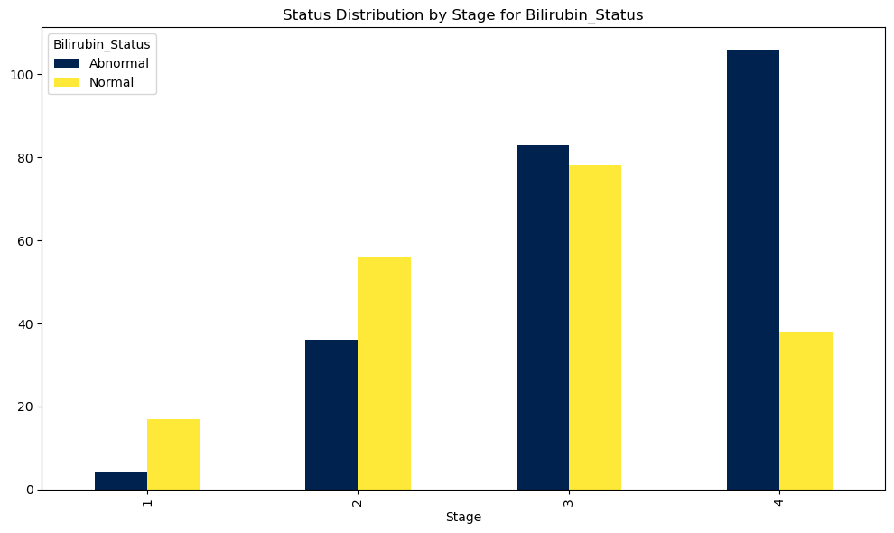

```python
#Plotting from Bilirubin Status

feature_analysis_plot(df1, 'Bilirubin_Status')
```

Status 1: Bilirubin

From this plot, we can see that distribution of bilirubin status across different disease stages reveals a trend in which the proportion of individuals with abnormal bilirubin levels increases as the disease stage progresses. Overall, the data shows that as the disease progresses from Stage 1 to Stage 4, the prevalence of abnormal bilirubin levels increases, with a marked transition at Stage 3 and a clear dominance of abnormal values at Stage 4. This suggests that bilirubin status may be an important marker for assessing the severity of liver disease.

Let's do further attribute analysis

```
Copper_Status  Abnormal  Normal
Stage
1                     2      19
2                     9      83
3                    24     137
4                    32     112
```

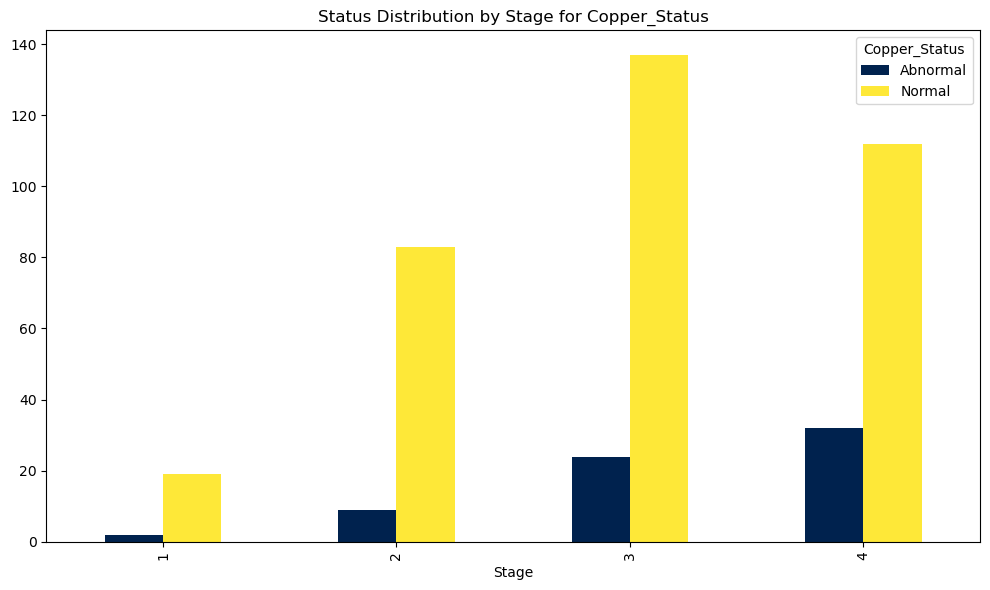

```python
#Plotting from Copper Status

feature_analysis_plot(df1, 'Copper_Status')
```

Status 2: Copper

From this plot we can see that mostly, cirrhosis patient with higher stage are the one that suffer from abnormal level of copper, indicating that copper level can be the indicator for determining the severity level

```
SGOT_Status  Abnormal  Normal
Stage
1                  21       0
2                  91       1
3                 160       1
4                 144       0
```

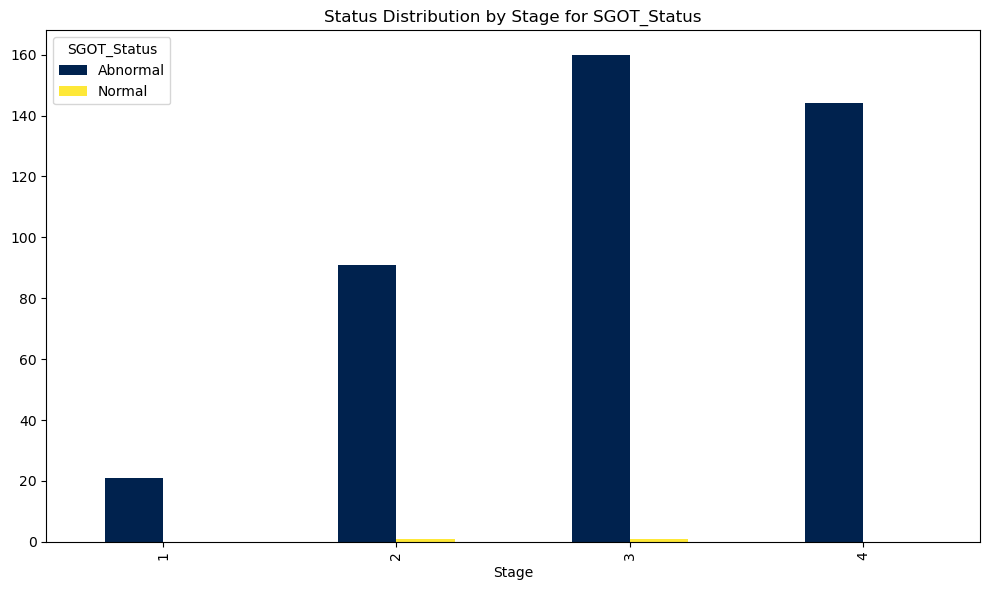

```python
#Plotting from SGOT Status

feature_analysis_plot(df1, 'SGOT_Status')
```

Status 3: SGOT

Seems like from the previous plot, the normal data is only a noise, meaning that mostly patient with cirrhosis would suffer from abnormal level of SGOT, only a rare few don't

```
Triglycerides_Status  Abnormal  Normal
Stage
1                            1      20
2                           11      81
3                           36     125
4                           24     120
```

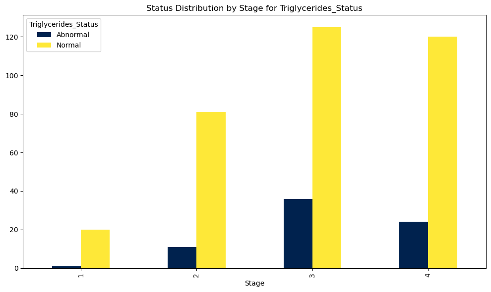

```python
#Plotting from Triglycerides Status

feature_analysis_plot(df1, 'Triglycerides_Status')
```

Status 4: Triglycerides

```
Platelets_Status  Abnormal  Normal
Stage
1                        1      20
2                        7      85
3                       14     147
4                       37     107
```

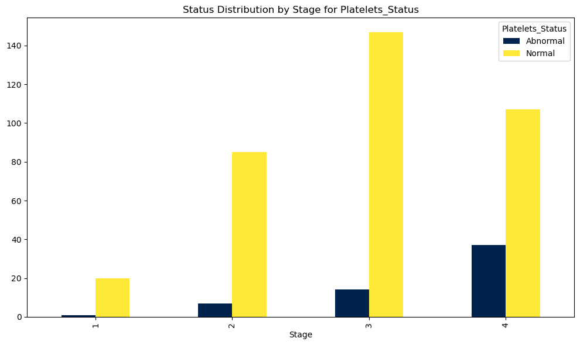

```python
#Plotting from Platelets Status

feature_analysis_plot(df1, 'Platelets_Status')
```

Status 5: Platelets

Platelets or trombosit, can be indicator of hepatis cirrhosis. from this plot we can see that more severe the stage is, more patient with abnormal platelets level there are, and smaller the ratio between Normal:Abnormal

```python
#Feature insight analysis of bilirubin correlation with other condition
#(using the proportion of patients in each bilirubin_status group)
# condition_analysis = df1.groupby('Bilirubin_Status')[['Ascites', 'Edema', 'Hepatomegaly']].mean()
# condition_analysis
```

After seeing the feature analysis, we can see that every medical condition has different approach to hepatis cirrhosis severity stage. We will explore the numerical attributes to see if there are any notable patterns or correlations between these attributes and the different stages of liver disease.